# Bonafide F1 Predictions 2025

Sawyer Stein

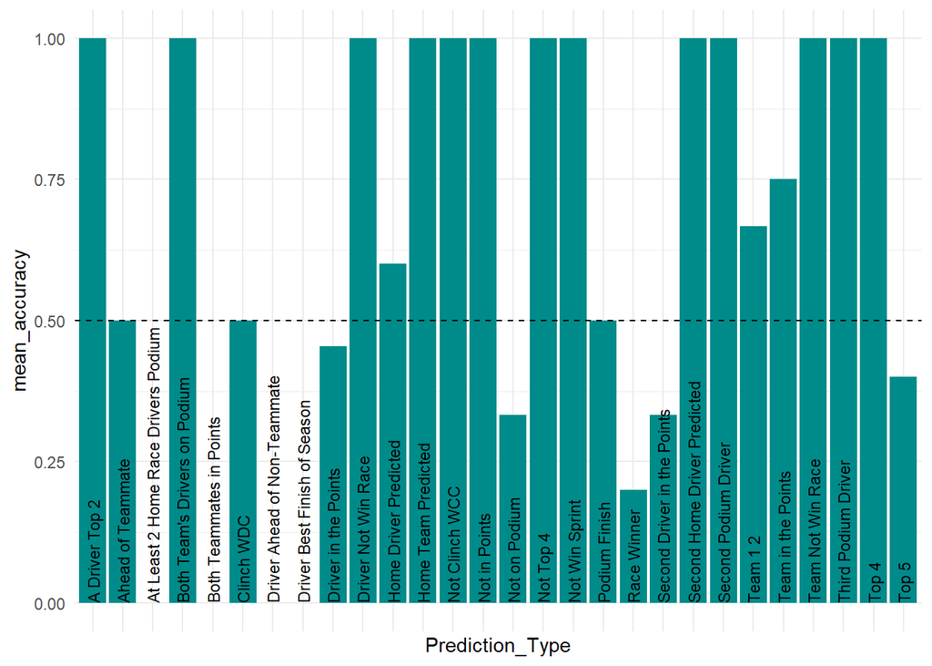

*This chart shows the average accuracy for each type of prediction. Some types of predictions appear easier to get right than others.*

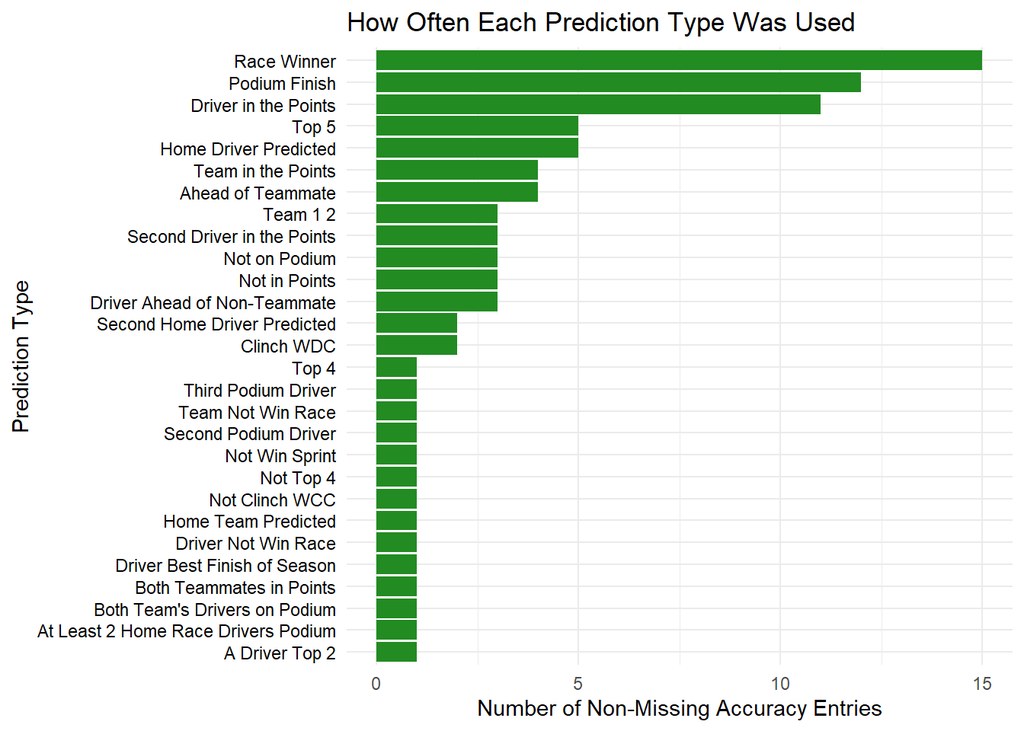

*This chart shows how often each type of prediction was actually used in the dataset. Some prediction types appear much more frequently than others.*

# Displays of Confidence Intervals:

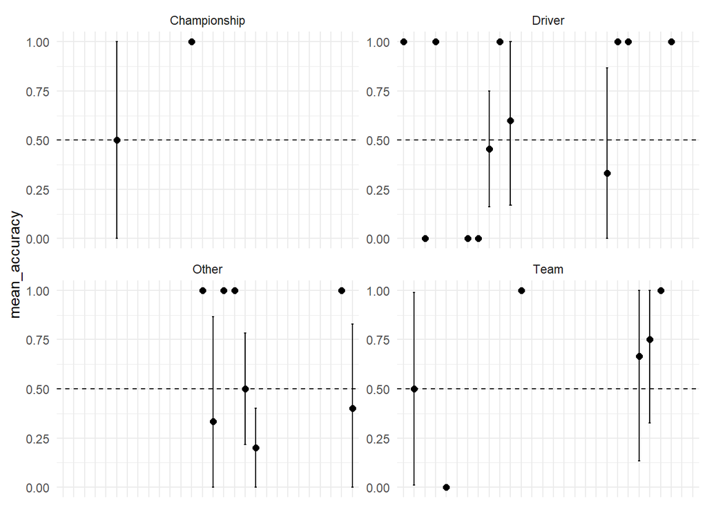

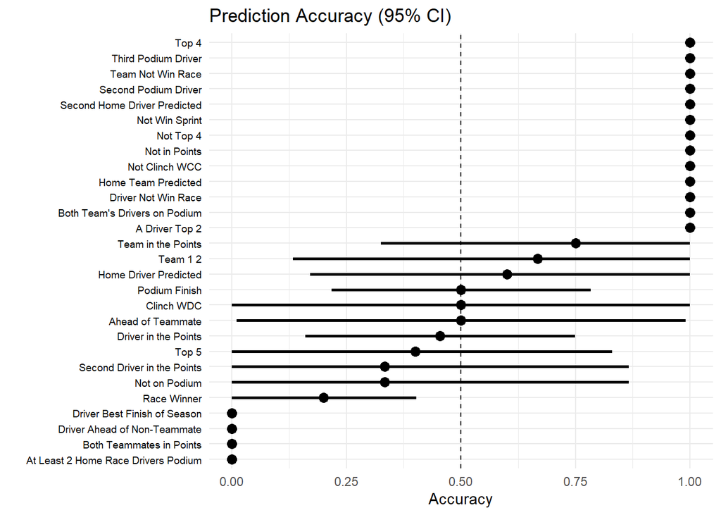

*This plot shows the average accuracy for each type of prediction along with a range showing uncertainty around the estimate. The dashed line at 50% represents the accuracy someone would expect if they were guessing randomly.*

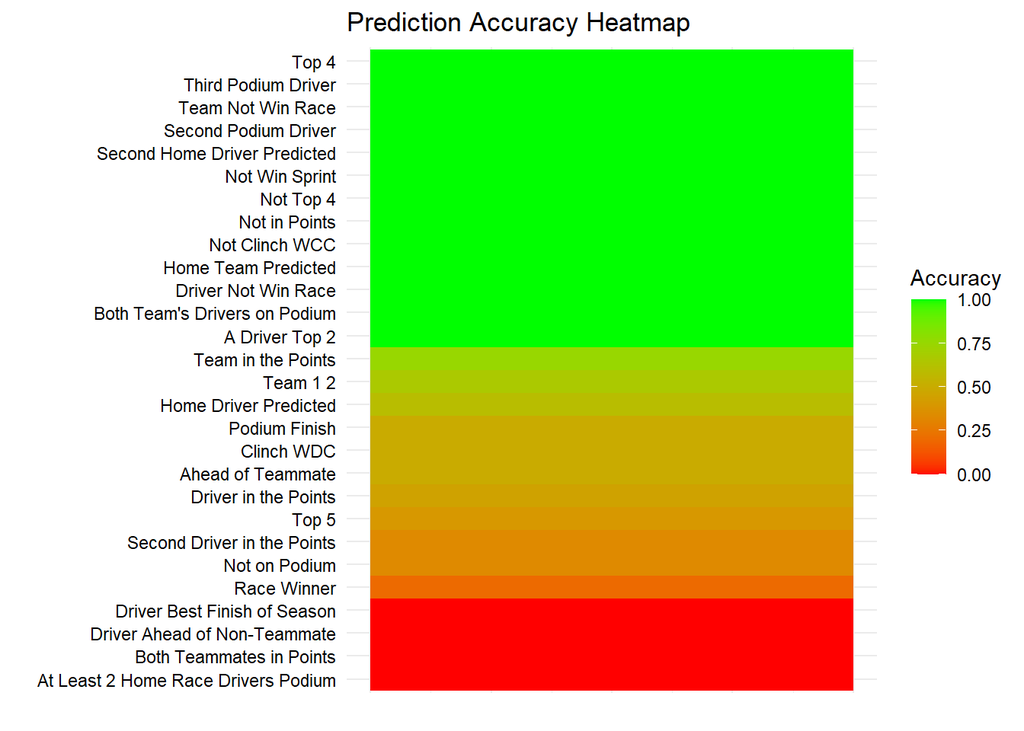

*This heatmap shows prediction accuracy using colors. Green areas represent higher accuracy, while red areas represent lower accuracy. This makes it easy to quickly see which prediction types performed better or worse.*

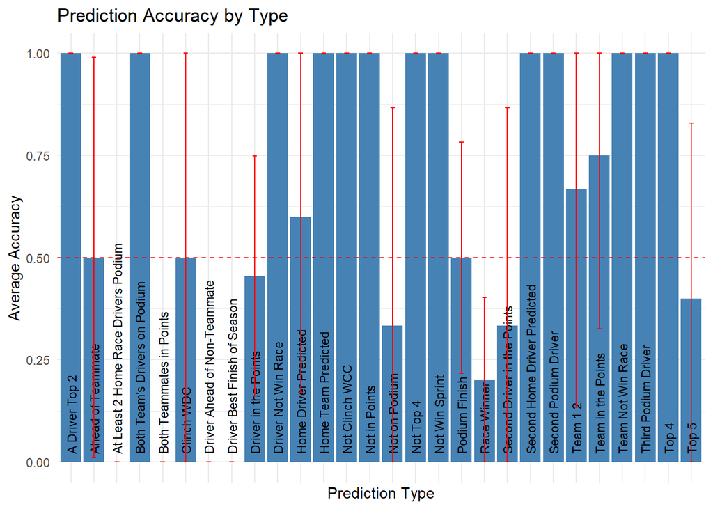

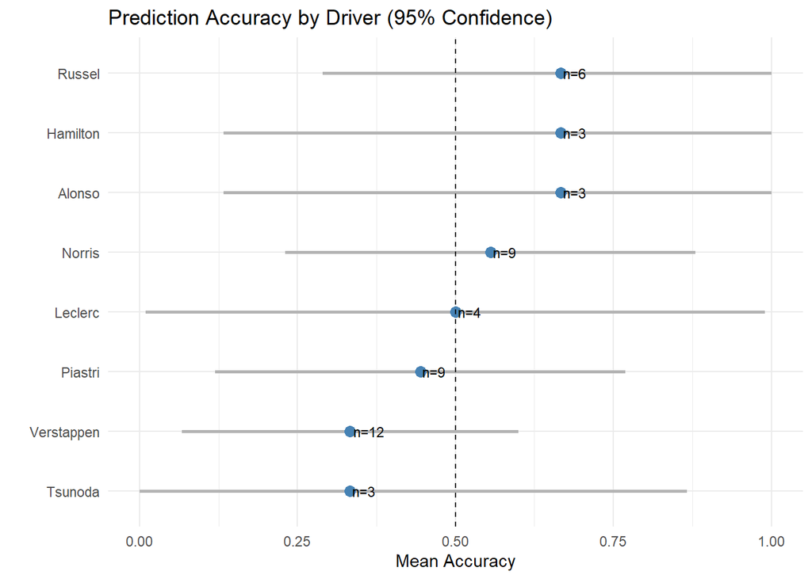

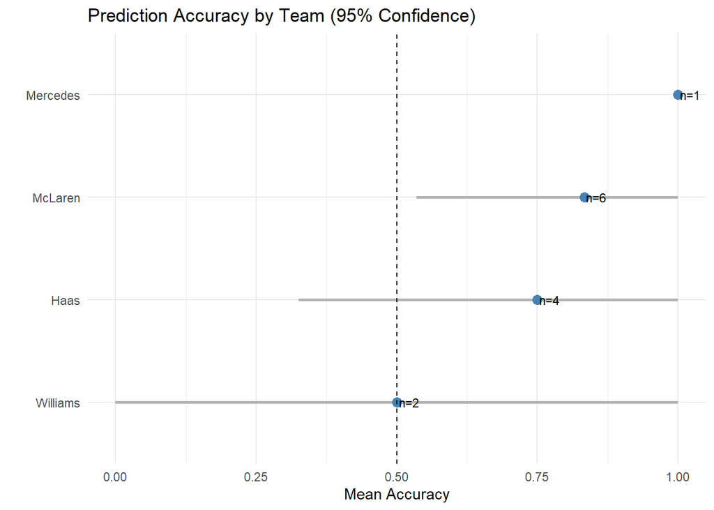

```
## # A tibble: 2 × 3
##   Group  mean_acc     n
##   <chr>     <dbl> <int>
## 1 Driver    0.484    62
## 2 Team      0.769    13
```

```
##
##  2-sample test for equality of proportions with continuity correction
##
## data:  tapply(combined$Accuracy, combined$Group, sum) out of tapply(combined$Accuracy, combined$Group, length)
## X-squared = 2.463, df = 1, p-value = 0.1166
## alternative hypothesis: two.sided
## 95 percent confidence interval:
##  -0.59251719  0.02179759
## sample estimates:
##    prop 1    prop 2
## 0.4838710 0.7692308
```

*This test checks whether the difference between driver prediction accuracy and team prediction accuracy is large enough to be meaningful. The results suggest the difference could easily happen by chance, so we cannot confidently say one type is better than the other.*

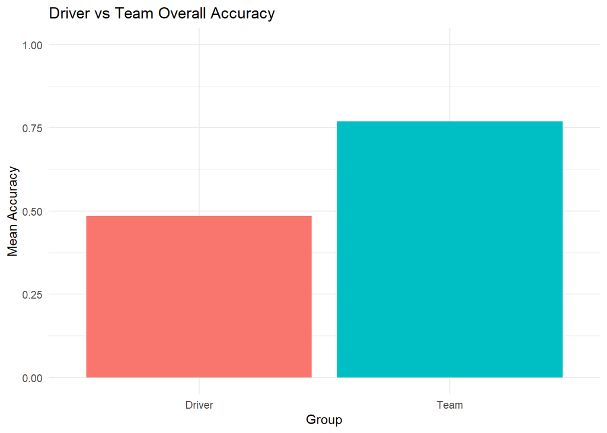

```
## # A tibble: 1 × 1
##   n_drivers
##       <int>
## 1         8
```

```
##
##  Pearson's Chi-squared test
##
## data:  driver_table2
## X-squared = 3.2031, df = 7, p-value = 0.8656
```

*This test checks whether some drivers are predicted correctly more often than others. The results show no clear evidence that the specific driver affects prediction accuracy.*

```
##    Min. 1st Qu.  Median    Mean 3rd Qu.    Max.
##   1.469   1.531   2.490   3.062   4.454   6.122
```

```
## Analysis of Deviance Table
##
## Model: binomial, link: logit
##
## Response: Accuracy
##
## Terms added sequentially (first to last)
##
##
##        Df Deviance Resid. Df Resid. Dev Pr(>Chi)
## NULL                      48     67.908
## Driver  7   3.2605        41     64.648   0.8599
```

*This model looks at whether knowing which driver was predicted helps explain whether the prediction was correct. The results suggest that the driver alone does not strongly explain prediction accuracy.*

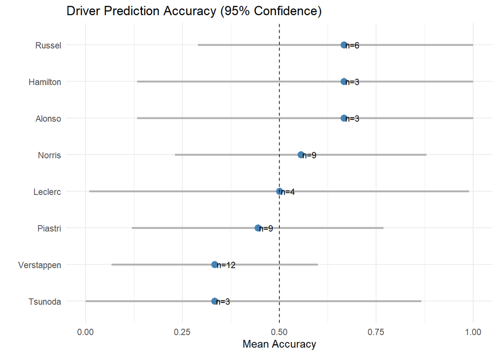

```
##                          Factor    p-value                          Conclusion
## 1            Which driver it is 0.85990840        No clear evidence it matters
## 2 What kind of prediction it is 0.02990349 Matters (statistically significant)
```

*This model checks whether the type of prediction helps explain whether the prediction was correct. The results suggest that prediction type may matter more than the driver being predicted.*

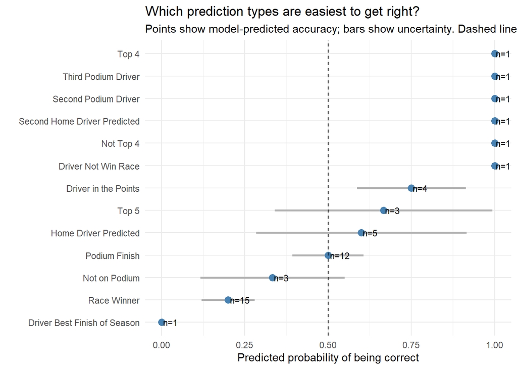

```
## Summary (controlling for both factors):
## - Which driver it is:does NOT show clear evidence of mattering. (p =0.86)
## - What kind of prediction it is:matters. (p =0.03)
##
## Interpretation:
## Accuracy differences are driven more by the TYPE of prediction than by the specific driver.
```

Plot of Info:

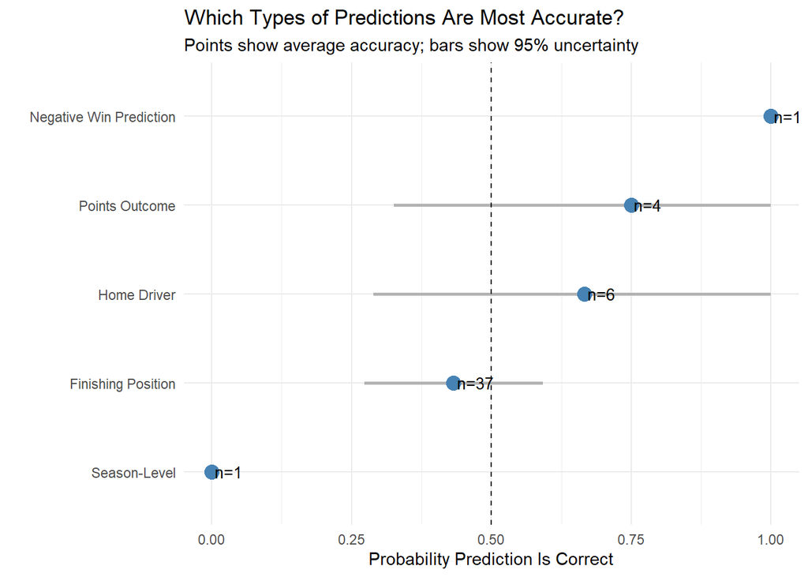

*Prediction accuracy varies more by prediction type than by driver. Predictions that a driver will not win are highly accurate, likely because race wins are rare events. In contrast, season-level predictions are the least accurate, suggesting that long-term performance is more difficult to forecast than race-level outcomes.*

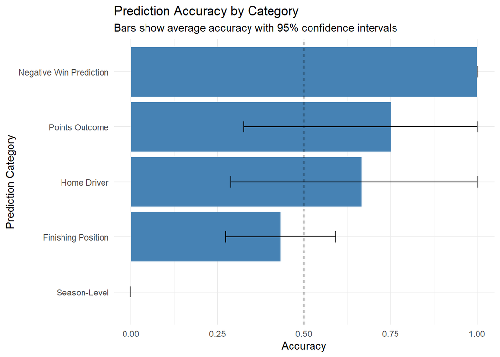

# Is L-Bone a Lando Jinx?

```
## # A tibble: 2 × 4
##   pred_norris total_predictions correct_predictions accuracy_rate
##   <lgl>                   <int>               <int>         <dbl>
## 1 FALSE                       9                   1         0.111
## 2 TRUE                        6                   2         0.333
```

```
##
##         FALSE TRUE
##   FALSE     8    1
##   TRUE      4    2
```

```
##
##  Fisher's Exact Test for Count Data
##
## data:  tab
## p-value = 0.956
## alternative hypothesis: true odds ratio is less than 1
## 95 percent confidence interval:
##    0.0000 129.8356
## sample estimates:
## odds ratio
##   3.622029
```

*This test checks whether predictions involving Lando Norris were more likely to be wrong. The results show no evidence that predicting Norris leads to worse results.*

```
## [1] 0.9557
```

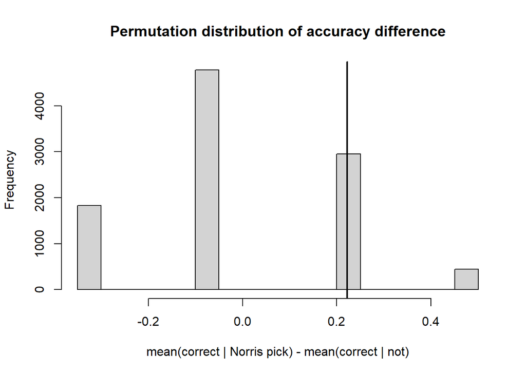

*This plot shows what the difference in prediction accuracy would look like if there were no real effect from picking Norris. The bars show results from many random re-shuffles of the data. The vertical line shows the actual difference we observed in the real predictions. Because the line falls well within the range of the random results, it suggests the difference could easily happen by chance. In simple terms, the plot supports the idea that picking Norris does not meaningfully change prediction accuracy.*

```
## [1] 0.2
```

```
## [1] 0.3333333
```

# RACE WINNER PREDICTION ACCURACY:

```
## # A tibble: 4 × 3
##   predicted_driver total_predictions accuracy_rate
##   <chr>                        <int>         <dbl>
## 1 russel                           1         0
## 2 verstappen                       4         0
## 3 piastri                          4         0.25
## 4 norris                           6         0.333
```

# RACE WINNER PREDICTIONS:

```
## # A tibble: 15 × 3
##    race           predicted_driver correct
##    <chr>          <chr>            <lgl>
##  1 Australia      verstappen       FALSE
##  2 Saudi Arabia   verstappen       FALSE
##  3 Miami          norris           FALSE
##  4 Emilia-Romagna norris           FALSE
##  5 Monaco         verstappen       FALSE
##  6 Great Britain  norris           TRUE
##  7 Belgium        piastri          TRUE
##  8 Hungary        norris           TRUE
##  9 Netherlands    norris           FALSE
## 10 Italy          piastri          FALSE
## 11 Azerbaijan     piastri          FALSE
## 12 Singapore      norris           FALSE
## 13 United States  piastri          FALSE
## 14 Mexico         verstappen       FALSE
## 15 Brazil         russel           FALSE
```

*This table shows each race winner prediction and whether it was correct. It allows us to see the full record of predictions race by race.*

Race-Winner Prediction Trajectory Story:

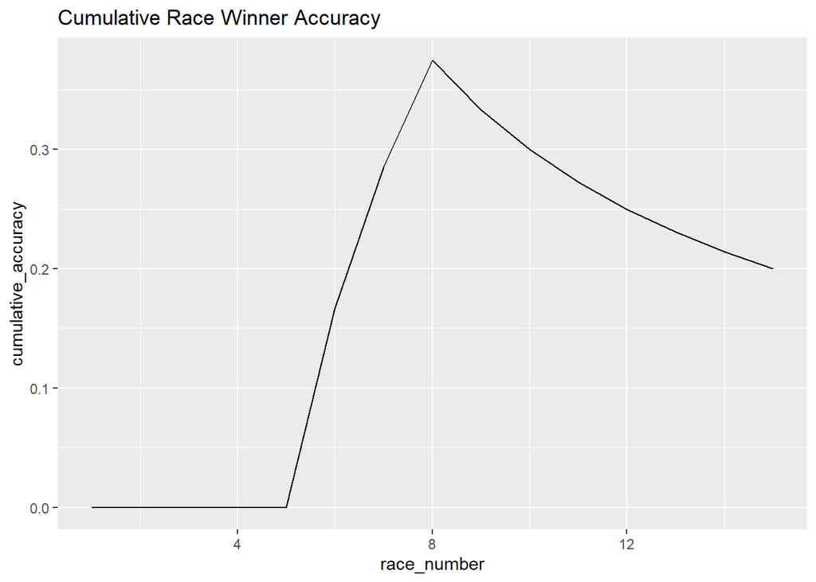

*Your race-winner predictions started off completely wrong, got a little better for a few races in the middle, and then slowly got worse again toward the end of the season. (L-BONE!!!)*